# M2.991_20241_PAC1-Enunciat-1

# Reducció de la dimensionalitat (2.5 punts)

En aquest apartat reprendrem l'anàlisi gràfica de la distribució de la classe al llarg de les mostres del conjunt de dades. En el segon apartat vam poder observar si les variables descriptives per separat eren molt prometedores o no per predir la classe. Aquí intentarem determinar si la seva combinació pot ajudar-nos a establir si es contractarà el dipòsit de manera més eficaç que utilitzant els atributs per separat. Amb aquest propòsit, reduirem la dimensionalitat del problema a només dos atributs, que seran la projecció dels atributs descriptius originals, i observarem com es distribueixen les mostres de cada classe.

**Exercici:**

- Aplica el mètode de reducció de la dimensionalitat Principal Component Analysis (PCA) per reduir a 2 dimensions el conjunt de dades complet amb tots els atributs (*features*).
- Genera un gràfic en 2D amb el resultat del PCA utilitzant colors diferents per a cadascuna de les classes de la resposta, amb l'objectiu de visualitzar si és possible separar eficientment les classes amb aquest mètode.

NOTA: Tingueu cura de no incloure la variable objectiu en la reducció de dimensionalitat. Volem explicar la variable objectiu en funció de la resta de variables reduïdes a dues dimensions.

Suggeriment: no és necessari que programeu l'algorisme de PCA, podeu utilitzar la implementació disponible a la llibreria de *scikit-learn*.

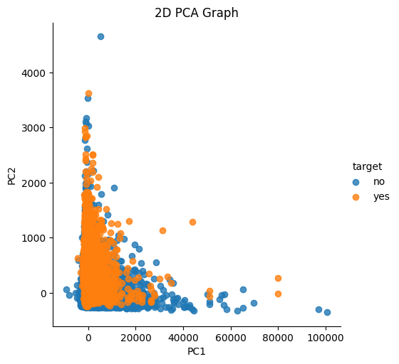

```python
import seaborn as sns
from sklearn.decomposition import PCA
X = bank_marketing[["age","balance","day","duration","campaign","pdays","previous"]]
y=bank_marketing["y"]
pca = PCA(n_components=2)
pca_features = pca.fit_transform(X)
pca_df = pd.DataFrame(
    data=pca_features,
    columns=['PC1', 'PC2'])
pca_df['target'] = y
sns.lmplot(
    x='PC1',
    y='PC2',
    data=pca_df,
    hue='target',
    fit_reg=False,
    legend=True
    )

plt.title('2D PCA Graph')
plt.show()
```

[output not shown]

**Exercici:**

- Repeteix la reducció de la dimensionalitat, però en aquest cas utilitzant TSNE. Podeu trobar més informació sobre aquest algorisme en l'enllaç: https://distill.pub/2016/misread-tsne/
- Igual que abans, genereu un gràfic en 2D amb el resultat del TSNE fent servir colors diferents per a cadascuna de les classes de la resposta (y), amb l'objectiu de visualitzar si és possible separar eficientment les classes amb aquest mètode.

Suggeriment: no és necessari que programeu l'algorisme TSNE, podeu fer servir la implementació disponible a la llibreria de *scikit-learn*.  
Suggeriment: a part d'especificar el nombre de components, proveu els paràmetres "learning_rate" i "perplexity".

```python
import seaborn as sns
from sklearn.manifold import TSNE
X = bank_marketing[["age","balance","day","duration","campaign","pdays","previous"]]
y=bank_marketing["y"]
tsne = TSNE(n_components=2 )
tsne_features = tsne.fit_transform(X)
```

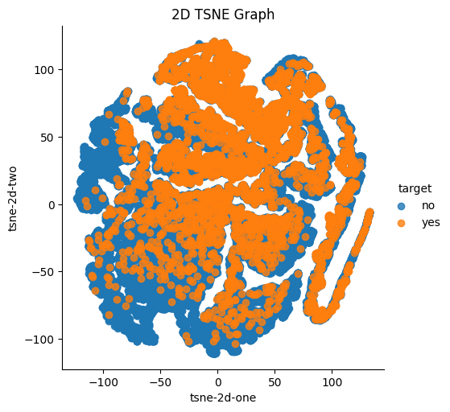

```python
tsne_df = pd.DataFrame(
    data=tsne_features,
    columns=['tsne-2d-one', 'tsne-2d-two'])
tsne_df['target'] = y
sns.lmplot(
    x='tsne-2d-one',
    y='tsne-2d-two',
    data=tsne_df,
    hue='target',
    fit_reg=False,
    legend=True
    )

plt.title('2D TSNE Graph')
plt.show()
```

**Anàlisi:** observant els dos gràfics, consideres que la reducció de dimensionalitat ha funcionat bé?. Ha aconseguit separar les classes correctament?. Quin dels dos mètodes ha funcionat millor?. Per què obtenim resultats tan diferents?

La diferència dels resultats és deguda al fet que els mètodes funcionen de manera molt diferent Principal Component Analysis (PCA): És una tècnica d'extracció de característiques: combina totes les variables d'entrada d'una manera específica, deixa anar les variables menys importants alhora que conserva les més valuoses. En aquest mètode calculem vectors propis i valors propis de la matriu de covariància. Una vegada que es troben vectors propis de la matriu de covariància, el següent pas és ordenar-los per valor propi, de més a menys. Això li dona els components per ordre de significació. El vector propi amb el valor propi més alt és el component principal del conjunt de dades. En el nostre cas específic ens quedem amb els 2 components amb valor propi més gran.

T-Distributed Stochastic Neighbor Embedding (t-SNE): t-SNE és una tècnica no lineal i no supervisada utilitzada principalment per a l'exploració de dades i visualització de dades d'alta dimensió. Et proporciona una intuïció de com les dades estan disposades en un espai d'alta dimensió. L'algorisme t-SNE calcula una mesura de semblança entre punts en l'espai d'alta dimensió utilitzant la distribució gaussiana i després en l'espai de baixa dimensió utilitzant la distribució Cauchy. Finalment, mesura la distribució de probabilitat dels espais bidimensionals mitjançant la divergència Kullback-Liebler i optimitza la funció de cost KL utilitzant descens de gradient.

PCA vs t-SNE: t-SNE difereix de PCA en preservar només petites distàncies parell a parell o similituds locals, mentre que PCA s'ocupa de preservar grans distàncies parell a parell per maximitzar la variància. PCA és una tècnica de reducció de dimensió lineal que busca maximitzar la variància i preserva grans distàncies per parells. En altres paraules, les coses diferents acaben molt allunyades. Això pot portar a una mala visualització, especialment quan es tracta d'estructures de varietats no lineals.

La reducció de dimensionalitat sembla massa agressiva on en el PCA, ens farien falta més variables per poder predir, i no ha separat molt bé les classes, t-SNE sembla que ho ha fet millor sobretot quan els valors no estant al centre hi ha més separació de classes. En general, sembla que serà més fàcil predir un "no" serà que un "si", ja que hi ha "no" que no tenen cap "si" a prop però al revés no. Per exemple si la PC1 es gran i la PC2 es petita semba que sera que "no".

Respecte a quin mètode ha funcionat millor jo diria que com que T-SNE tècnicament no redueix dimensionalitat sinó que només és una eina per visualitzar, per tant clarament és inferior a PCA per l'objectiu de reduir dimensionalitat, ja que ell no ho pot fer.

**Pregunta:** Què en penses de TSNE com a opció per reduir la dimensionalitat? Què et sembla que només tingui el mètode "fit_transform" però no tingui "transform"? Coneixes alguna altra opció que, amb prestacions similars, eviti els problemes que té TSNE?

Com he dit abans t-SNE està pensat per visualitzar espais d'altes dimensions, per tant, el seu objectiu no és reduir la dimensionalitat per poder predir a partir d'aquesta transformació, en conseqüència, té molt sentit que només tingui fit_tranform perquè sempre que l'utilitzis ho faràs per mostrar un mapa de totes les dades, no per aplicar-ho a altres dades. I encara que volguessis, no es pot fer per com funciona l'algoritme, ja que no aprèn a fer una reducció de dimensionalitat sinó que a través d'un procés iteratiu en un subespai troba un equilibri que redueix la pèrdua de distància entre les dades. Una alternativa podria ser la funcio Isomap de sklean que es un metode de reucccio de dimensionalitat no lineal

# Conjunts desequilibrats de dades (2.5 punts)

En els problemes de classificació, és molt comú trobar conjunts de dades molt desequilibrats. En la indústria existeixen múltiples exemples, com ara la detecció de frau o la fuga de clients. Aquest apartat se centra en l’anàlisi d’aquest tipus de conjunts.

El cas del *dataset* amb el qual estem treballant (*Bank Marketing*) és un d’ells, ja que podem observar com la classe "no" apareix amb una freqüència fins a deu vegades més gran que la classe "yes".

A continuació, analitzarem la distribució del nostre conjunt de dades. Per fer-ho, farem servir la funció **show_distribution** definida a la següent cel·la:

```python
def show_distribution(y_df):
    freq = y_df["y"].value_counts()
    plt.pie(freq, labels=('No subscription ('+str(freq["no"])+')', 'Subscription ('+str(freq["yes"])+')'), autopct='%1.1f%%')
    plt.title("Term deposit subscription distribution")
    plt.show()
```

```python
def show_distribution_simple(y_df):
    freq = y_df.value_counts()
    plt.pie(freq, labels=('No subscription ('+str(freq["no"])+')', 'Subscription ('+str(freq["yes"])+')'), autopct='%1.1f%%')
    plt.title("Term deposit subscription distribution")
    plt.show()
```

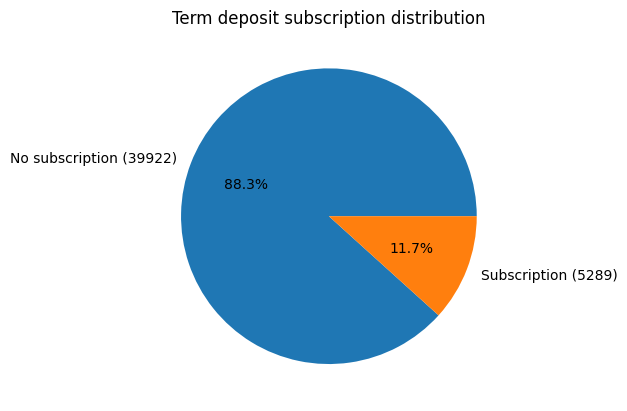

```python
show_distribution(bank_marketing)
```

Com es pot observar, el conjunt està força desequilibrat, ja que, pràcticament, només una desena part de les mostres corresponen a la contractació del dipòsit.

Per tractar el problema de dades desequilibrades, analitzarem la tècnica de sobremostreig (*oversampling*) de la classe minoritària. A la literatura hi ha més tècniques per afrontar aquest problema, com el submostreig (*undersampling*) de la classe majoritària, però en aquesta PAC, ens centrarem només en la tècnica de sobremostreig.

## Oversampling

**Exercici:** incrementeu les mostres de la classe minoritària fins a arribar a un nombre similar al dels elements de la classe majoritària aplicant les tècniques següents:

- Duplicació aleatòria (_random over-sampling_), fixant random_state=10.
- SMOTE (_Synthetic Minority Over-sampling Technique_), fixant random_state=10.
- ADASYN (_Adaptive Synthetic Sampling_), fixant random_state=10.

Per acabar, verifiqueu amb l’ajuda de la funció **show_distribution**, que després de l’aplicació d’aquestes tècniques, el nombre de mostres de la classe minoritària s’ha igualat al de la majoritària.

Suggeriment: per aplicar la replicació aleatòria podeu fer servir "RandomOverSampler" d'*imblearn*.  
Suggeriment: per aplicar SMOTE podeu utilitzar "SMOTE" d'*imblearn*.  
Suggeriment: per aplicar ADASYN podeu utilitzar "ADASYN" d'*imblearn*.

```python
from imblearn.over_sampling import RandomOverSampler
ros = RandomOverSampler(random_state=10)
X_resampled_random, y_resampled_random = ros.fit_resample(X, y)
```

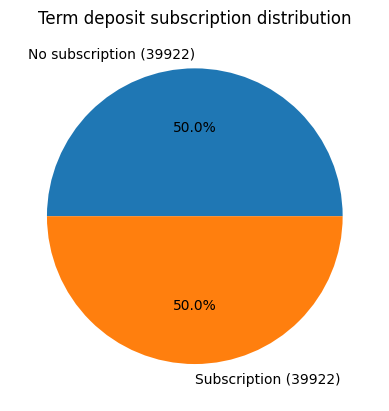

```python
show_distribution_simple(y_resampled_random)
```

```python
from imblearn.over_sampling import SMOTE
sm = SMOTE(random_state=10)
X_resampled_SMOTE, y_resampled_SMOTE = sm.fit_resample(X, y)
```

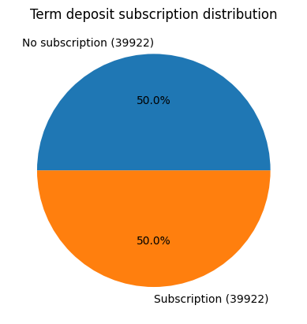

```python
show_distribution_simple(y_resampled_SMOTE)
```

```python
from imblearn.over_sampling import ADASYN
ada = ADASYN(random_state=10)
X_resampled_ADASYN, y_resampled_ADASYN = ada.fit_resample(X, y)
```

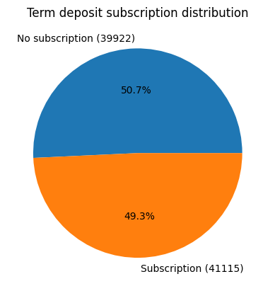

```python
show_distribution_simple(y_resampled_ADASYN)
```

El resultat d'aplicar aquestes tècniques hauria d'haver produit un nombre similar de mostres per a les dues classes. No obstant això, cadascun dels mètodes genera les noves mostres de la classe minoritària de manera diferent. Amb l'objectiu de comprendre millor i de manera visual com es generen aquestes noves mostres, a partir d'ara, farem servir la descomposició a dues dimensions que hagi mostrat un millor comportament a l'apartat anterior.

**Exercici:** mostreu, amb un gràfic de dispersió en funció de les dues components resultants de la reducció dimensional prèvia, la distribució de les contractacions del conjunt de dades original, i del que s'ha obtingut després d'aplicar Random Over Sampling.

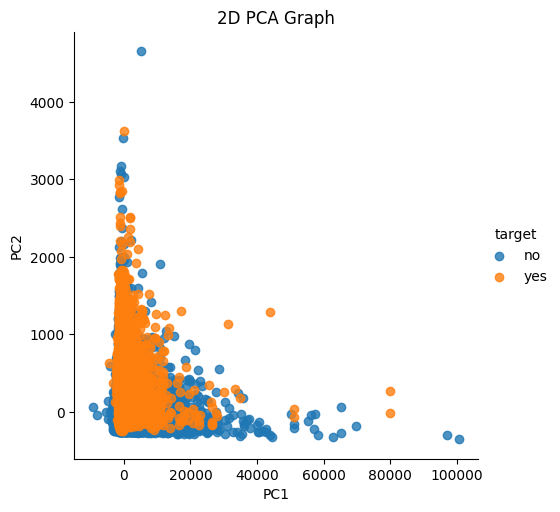

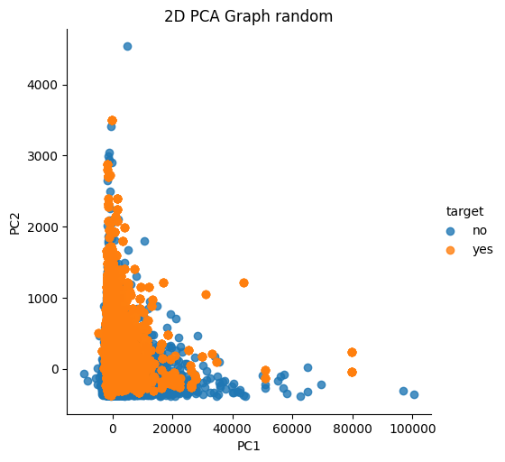

```python
X = bank_marketing[["age","balance","day","duration","campaign","pdays","previous"]]
y=bank_marketing["y"]
pca = PCA(n_components=2)
pca_features = pca.fit_transform(X)
pca_df = pd.DataFrame(
    data=pca_features,
    columns=['PC1', 'PC2'])
pca_df['target'] = y
sns.lmplot(
    x='PC1',
    y='PC2',
    data=pca_df,
    hue='target',
    fit_reg=False,
    legend=True
    )

plt.title('2D PCA Graph')
plt.show()
pca = PCA(n_components=2)
pca_features = pca.fit_transform(X_resampled_random)
pca_df = pd.DataFrame(
    data=pca_features,
    columns=['PC1', 'PC2'])
pca_df['target'] = y_resampled_random
sns.lmplot(
    x='PC1',
    y='PC2',
    data=pca_df,
    hue='target',
    fit_reg=False,
    legend=True
    )

plt.title('2D PCA Graph random')
plt.show()
```

**Anàlisi:** Quines diferències i similituds trobes en les dues imatges anteriors? Justifiqueu la resposta tenint en compte la distribució d’ambdós conjunts, és a dir, la quantitat d’avaries de motor.

Òbviament, la variable "no" no ha variat, ja que tenim les mateixes dades i la que si tampoc ha variat en distribució, només ara està més poblada on també teníem punts abans, per tant, veiem més densitat de punts al sí, però no veiem canvis en la distribució de punts, pel fet que només hem duplicat els punts existents de manera aleatòria.

**Exercici:** mostreu, amb un gràfic de dispersió en funció de les dues components resultants de la reducció dimensional prèvia, la distribució de les contractacions dels tres conjunts de dades obtinguts en aplicar les tres tècniques de sobremostreig.

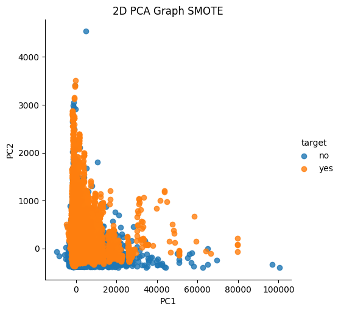

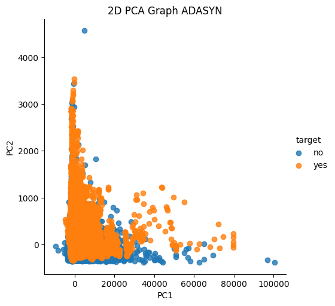

```python
pca = PCA(n_components=2)
pca_features = pca.fit_transform(X_resampled_SMOTE)
pca_df = pd.DataFrame(
    data=pca_features,
    columns=['PC1', 'PC2'])
pca_df['target'] = y_resampled_SMOTE
sns.lmplot(
    x='PC1',
    y='PC2',
    data=pca_df,
    hue='target',
    fit_reg=False,
    legend=True
    )

plt.title('2D PCA Graph SMOTE')
plt.show()
pca = PCA(n_components=2)
pca_features = pca.fit_transform(X_resampled_ADASYN)
pca_df = pd.DataFrame(
    data=pca_features,
    columns=['PC1', 'PC2'])
pca_df['target'] = y_resampled_ADASYN
sns.lmplot(
    x='PC1',
    y='PC2',
    data=pca_df,
    hue='target',
    fit_reg=False,
    legend=True
    )

plt.title('2D PCA Graph ADASYN')
plt.show()
```

**Anàlisi:** considerant el nombre de mostres amb contractació en cada conjunt, comenteu les diferències i semblances a les imatges de l’exercici anterior. Justifiqueu la resposta tenint en compte el comportament de cadascuna de les tècniques utilitzades.